# Replication of Source Study

### Zachary Traylor’s Master’s Thesis

Return to Main Page

### ERP and Gamma Activity Relative to Baseline

As our processing steps differed slightly from the original publication, a comparison of ERP components and Gamma activity to the baseline period was performed to ensure that the data was collected at least *somewhat* similarly.

First, all four conditions’ data is loaded.

```r
erp1 <- read_csv("Data/Perception_erp.csv", col_types = cols(...1 = col_skip(),
                Sex = col_factor(levels = c("male", "female")),
                Stimulus = col_factor(levels = c("1", "2", "3"))))
erp1$Condition <- "Perception"
erp2 <- read_csv("Data/EDA_erp.csv", col_types = cols(...1 = col_skip(),
                Sex = col_factor(levels = c("male", "female")),
                Stimulus = col_factor(levels = c("1", "2", "3"))))
erp2$Condition <- "EDA"
erp3 <- read_csv("Data/Motor_erp.csv", col_types = cols(...1 = col_skip(),
                Sex = col_factor(levels = c("male", "female")),
                Stimulus = col_factor(levels = c("1", "2", "3"))))
erp3$Condition <- "Motor"
erp4 <- read_csv("Data/Control_erp.csv", col_types = cols(...1 = col_skip(),
                Sex = col_factor(levels = c("male", "female")),
                Stimulus = col_factor(levels = c("1", "2", "3"))))
erp4$Condition <- "Control"
erp <- do.call("rbind", list(erp1, erp2, erp3, erp4))

erp <- erp[!duplicated(erp), ]  # remove duplicate rows
erp <- subset(erp, erp$ID!=18)  # exclude subject 18 (DNF motor)
```

Then, the data is cleaned. Any missing data is removed (NAs here indicate that no negative/positive peak was found in the given time window).

```r
erp <- na.omit(erp)
```

We can then visually inspect the ERP components relative to their baseline

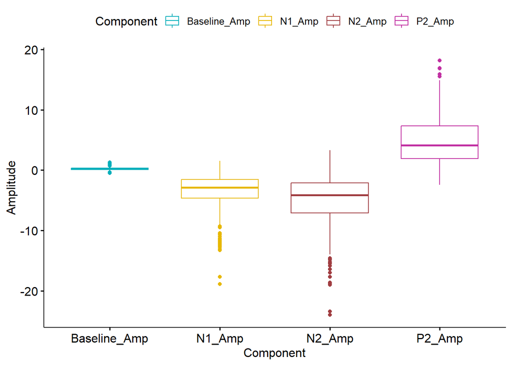

```r
ggboxplot(subset(erp, grepl("Amp", erp$Component, fixed = TRUE)),
          x="Component", y="Value",
          color = "Component", palette = c("#00AFBB", "#E7B800", "#A03D41", "#C130A2"),
          ylab = "Amplitude", xlab = "Component",
          order = c("Baseline_Amp", "N1_Amp", "N2_Amp", "P2_Amp"))
```

To confirm our visual inspection, we also run pairwise t-tests to compare ERP amplitudes to baseline.

```r
difference <- function(df, title, ignore){
  baseline <- subset(df, df$Component=="Baseline_Amp" & !(df$ID %in% ignore))
  test <- subset(df, df$Component==title & !(df$ID %in% ignore))
  # sub-sampling baseline so it equals test in length
  baseline <- baseline[sample(nrow(baseline), length(test$Value)), ]

  data <- rbind(baseline, test)

  # check that the difference is close enough to normal
  d <- baseline$Value - test$Value
  hist(d)

  pairwise_t_test(data, Value ~ Component, paired = TRUE, p.adjust.method = "bonferroni")
}
```

**N1 vs Baseline**

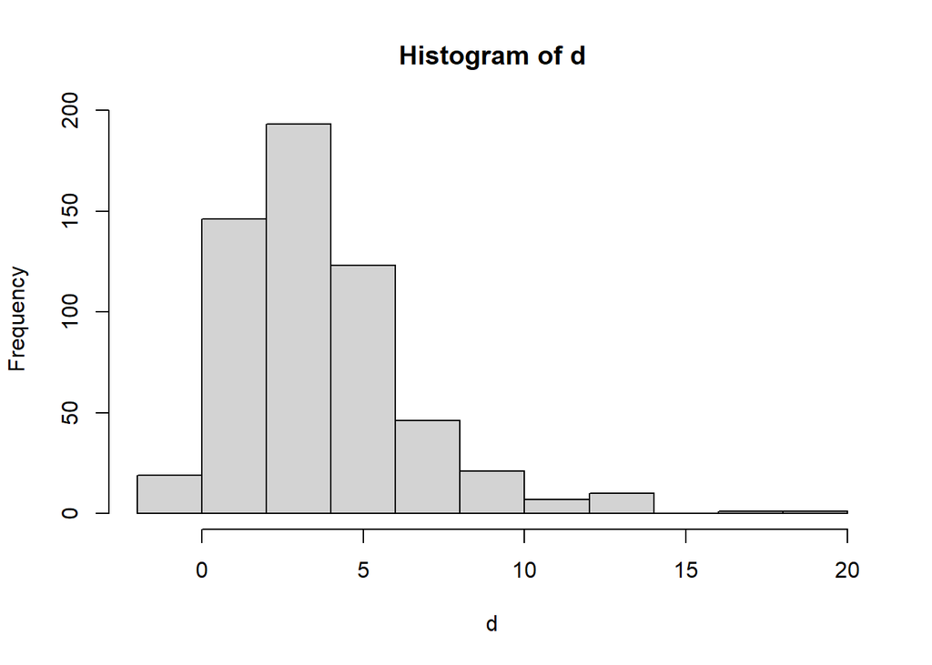

```
## # A tibble: 1 × 10
##   .y.   group1      group2    n1    n2 stati…¹    df         p     p.adj p.adj…²
## * <chr> <chr>       <chr>  <int> <int>   <dbl> <dbl>     <dbl>     <dbl> <chr>
## 1 Value Baseline_A… N1_Amp   567   567    31.3   566 2.12e-125 2.12e-125 ****
## # … with abbreviated variable names ¹statistic, ²p.adj.signif
```

```r
difference(erp, "N1_Amp", ignore=c(10, 19))
```

**N2 vs Baseline**

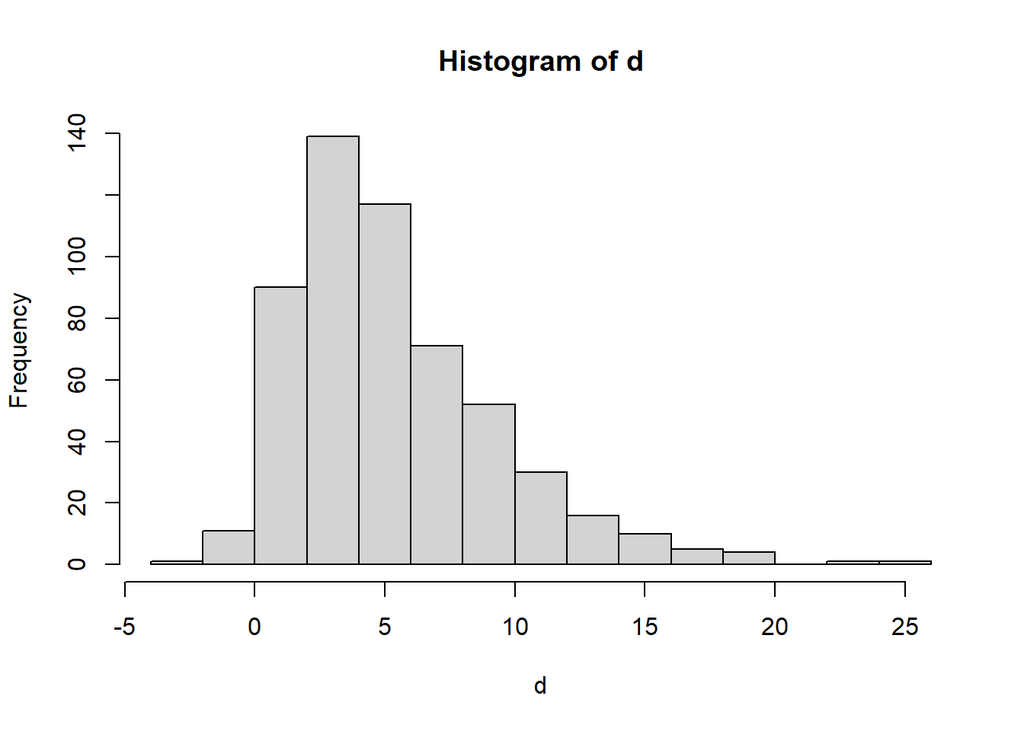

```
## # A tibble: 1 × 10
##   .y.   group1      group2    n1    n2 stati…¹    df         p     p.adj p.adj…²
## * <chr> <chr>       <chr>  <int> <int>   <dbl> <dbl>     <dbl>     <dbl> <chr>
## 1 Value Baseline_A… N2_Amp   548   548    31.5   547 6.32e-125 6.32e-125 ****
## # … with abbreviated variable names ¹statistic, ²p.adj.signif
```

```r
difference(erp, "N2_Amp", ignore=c(3, 19, 31, 32))
```

**P2 vs Baseline**

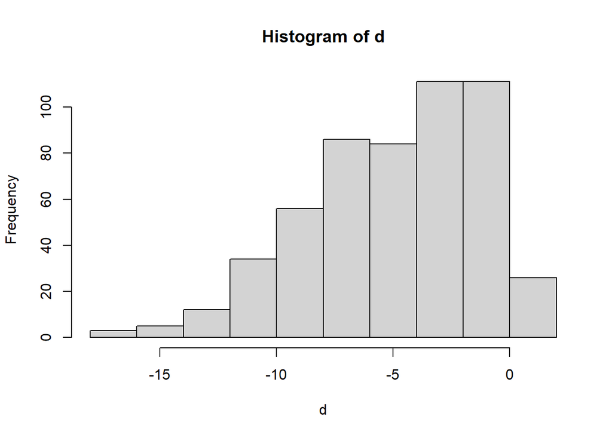

```
## # A tibble: 1 × 10
##   .y.   group1      group2    n1    n2 stati…¹    df         p     p.adj p.adj…²
## * <chr> <chr>       <chr>  <int> <int>   <dbl> <dbl>     <dbl>     <dbl> <chr>
## 1 Value Baseline_A… P2_Amp   528   528   -30.2   527 5.96e-117 5.96e-117 ****
## # … with abbreviated variable names ¹statistic, ²p.adj.signif
```

```r
difference(erp, "P2_Amp", ignore=c(5, 8, 15, 23, 43))
```

Next, the same steps are take for the gamma band power. Here, it is not necessary to omit NAs, as they are impossible.

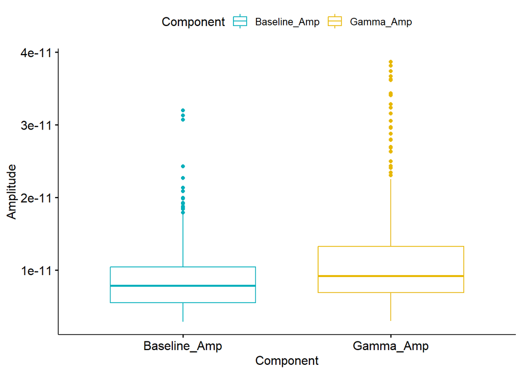

```r
gamma1 <- read_csv("Data/Perception_freq_G.csv", col_types = cols(...1 = col_skip(),
                                              Sex = col_factor(levels = c("male", "female")),
                                              Stimulus = col_factor(levels = c("1", "2", "3"))))
gamma1$Condition <- "Perception"
gamma2 <- read_csv("Data/EDA_freq_G.csv", col_types = cols(...1 = col_skip(),
                                              Sex = col_factor(levels = c("male", "female")),
                                              Stimulus = col_factor(levels = c("1", "2", "3"))))
gamma2$Condition <- "EDA"
gamma3 <- read_csv("Data/Motor_freq_G.csv", col_types = cols(...1 = col_skip(),
                                              Sex = col_factor(levels = c("male", "female")),
                                              Stimulus = col_factor(levels = c("1", "2", "3"))))
gamma3$Condition <- "Motor"
gamma4 <- read_csv("Data/Control_freq_G.csv", col_types = cols(...1 = col_skip(),
                                              Sex = col_factor(levels = c("male", "female")),
                                              Stimulus = col_factor(levels = c("1", "2", "3"))))
gamma4$Condition <- "Control"
gamma <- do.call("rbind", list(gamma1, gamma2, gamma3, gamma4))

gamma <- gamma[!duplicated(gamma), ]  # remove duplicate rows
gamma <- subset(gamma, gamma$ID!=18)  # exclude subject 18 (DNF motor)

ggboxplot(subset(gamma, grepl("Amp", gamma$Component, fixed = TRUE)),
          x="Component", y="Value",
          color = "Component", palette = c("#00AFBB", "#E7B800"),
          ylab = "Amplitude", xlab = "Component",
          order = c("Baseline_Amp", "Gamma_Amp"))
```

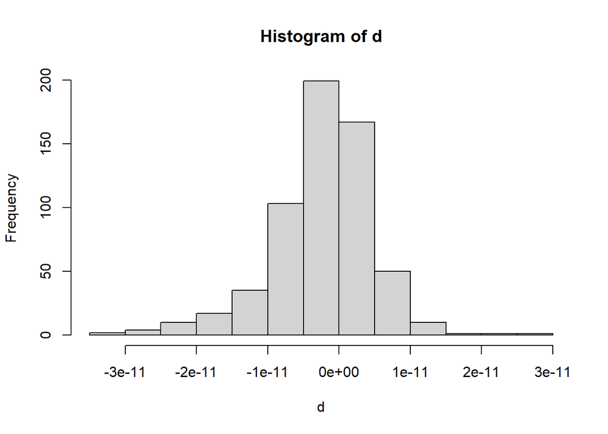

```
## # A tibble: 1 × 10
##   .y.   group1       group2     n1    n2 stati…¹    df        p    p.adj p.adj…²
## * <chr> <chr>        <chr>   <int> <int>   <dbl> <dbl>    <dbl>    <dbl> <chr>
## 1 Value Baseline_Amp Gamma_…   600   600   -8.19   599 1.63e-15 1.63e-15 ****
## # … with abbreviated variable names ¹statistic, ²p.adj.signif
```

```r
difference(gamma, "Gamma_Amp", ignore=c())
```

### Replicating the Findings of the Original Paper

The original paper reported a significant effect of stimulus intensity on all amplitudes (ERP and Gamma) and a significant effect of condition on N1 and Gamma amplitude. We are not interested in this component, but will still check if stimulus intensity significantly modulated amplitudes via the same repeated measures ANOVA.

```r
signif <- function(p) {
  val <- list()
  for (i in seq_len(length(p))){
    if (p[i] < 0.001) {val <- append(val, "***")}
    else if (p[i] < 0.01) {val <- append(val, "**")}
    else if (p[i] < 0.05) {val <- append(val, "*")}
    else if (p[i] < 0.1) {val <- append(val, ".")}
    else if (p[i] >= 0.1) {val <- append(val, " ")}
  }
  return(val)
}

simple_model <- function(df, title) {
  temp <- subset(df, df$Component==title)
  temp <- temp[!duplicated(temp), ]  # remove any duplicated rows

  simple.model <- aov_ez(id = "ID",
                         dv = "Value",
                         data = temp,
                         within = c("Stimulus", "Condition"),
                         fun_aggregate = mean)
  knitr::kable(nice(simple.model))
}
```

**N1 variance explained by Stimulus**

```r
simple_model(erp, "N1_Amp")
```

| Effect | df | MSE | F | ges | p.value |
| --- | --- | --- | --- | --- | --- |
| Stimulus | 1.49, 62.70 | 2.46 | 3.11 + | .003 | .066 |
| Condition | 2.16, 90.59 | 11.87 | 8.29 *** | .053 | <.001 |
| Stimulus:Condition | 4.67, 196.15 | 1.23 | 1.73 | .003 | .134 |

$~$

**N2 variance explained by Stimulus**

```r
simple_model(erp, "N2_Amp")
```

| Effect | df | MSE | F | ges | p.value |
| --- | --- | --- | --- | --- | --- |
| Stimulus | 1.39, 58.53 | 5.32 | 7.36 ** | .007 | .004 |
| Condition | 2.81, 117.85 | 27.60 | 2.88 * | .027 | .042 |
| Stimulus:Condition | 5.25, 220.37 | 2.15 | 1.17 | .002 | .325 |

$~$

**P2 variance explained by Stimulus**

```r
simple_model(erp, "P2_Amp")
```

| Effect | df | MSE | F | ges | p.value |
| --- | --- | --- | --- | --- | --- |
| Stimulus | 1.51, 52.82 | 3.27 | 31.65 *** | .028 | <.001 |
| Condition | 2.93, 102.45 | 21.47 | 3.58 * | .040 | .017 |
| Stimulus:Condition | 4.79, 167.70 | 2.57 | 1.01 | .002 | .410 |

$~$

**Gamma variance explained by Stimulus**

```r
simple_model(gamma, "Gamma_Amp")
```

| Effect | df | MSE | F | ges | p.value |
| --- | --- | --- | --- | --- | --- |
| Stimulus | 2, 98 | 0.00 | 16.06 *** | .004 | <.001 |
| Condition | 3, 147 | 0.00 | 5.77 *** | .040 | <.001 |
| Stimulus:Condition | 6, 294 | 0.00 | 1.35 | <.001 | .233 |